# Knitr Tutorial

Robert Paul

June 16, 2016

# Robert Paul

## University of Illinois at Urbana-Champaign

### Department of Plant Biology

I’m a PhD student student, and my main research interest is modeling trace gas flux biogeochemistry in plant-soil interactions within the context of climate change. I’m also driven to create and enjoy listening to podcasts, cooking, and geocaching.

My *learning goals* for the NEON Institute are…

- Getting a better understanding of hyperspectral and LiDAR data
- Linking observational data with remote sensing products to reveal deep ecological insights
- Learning methods of collaborative and reproducible science with version control/documentation
- Making cool images

## Capstone Project

My *current project* involves identifying and describing, through both observations and modeling, areas affected by intermittent flooding events. I would like to use the course to develop a robust, reproducible workflow to identify areas across a landscape where ponding and flooding events have occurred or are likely to occur after intense precipitation. Some of the data I expect to be useful are:

- **Landsat 8** NIR and SWIR bands
- **gSSURGO** raster soil data
- **Boulder, CO pre- and post-flooding 2013** LiDAR and hyperspectral data
- **LiDAR** data of sites with poorly-drained soils

## Some Raster Data Sets

```r
# Load libraries we'll need for LiDAR DTM/DSMs
library(rgdal)
library(raster)
library(knitr)

# Which system are we on?
currentSys <- Sys.info()["sysname"]

# Are we on Linux via the Chromebook?
if (currentSys == "Linux") {
  dataPath = "/media/removable/SD_128GB/Docs"
} else if (currentSys=="Darwin") { # Are we on the Macbook Pro?
  dataPath <- "/Users/exnihilo/Box Sync/Work/Workshops/NEONDI-2016/NEONdata/D17-California/TEAK/2013/lidar/"
}

# Set working directory
setwd(dataPath)
# Tell Knitr we're using a different root dir
opts_knit$set(root.dir=dataPath)
```

### Embedded Plots:

```r
# Get the surface raster for TEAK
teak_dsm <- raster("TEAK_lidarDSM.tif")
```

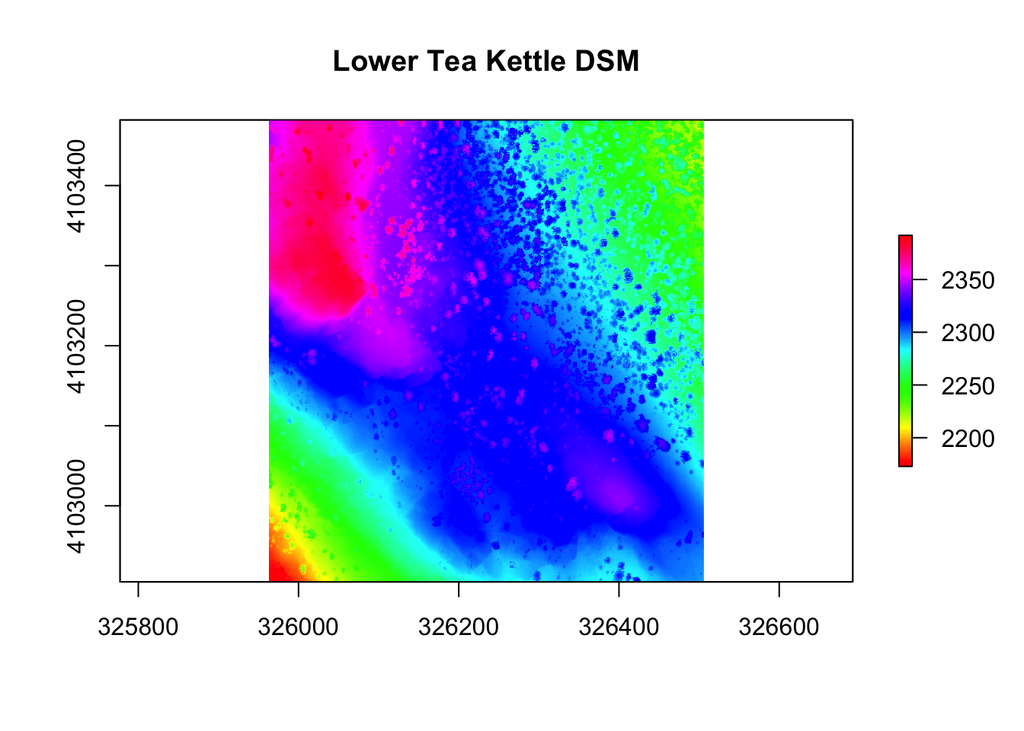

```r
# Plot the TEAK DSM raster
plot(teak_dsm, main="Lower Tea Kettle DSM", col=rainbow(250))
```

```r
# Get the CHM raster for TEAK
teak_chm <- raster("TEAK_lidarCHM.tif")
```

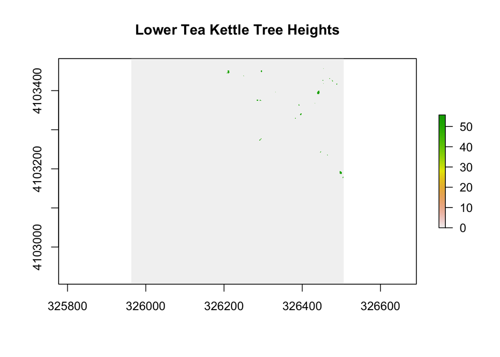

```r
# Plot the TEAK CHM raster
plot(teak_chm, main="Lower Tea Kettle Tree Heights")
```

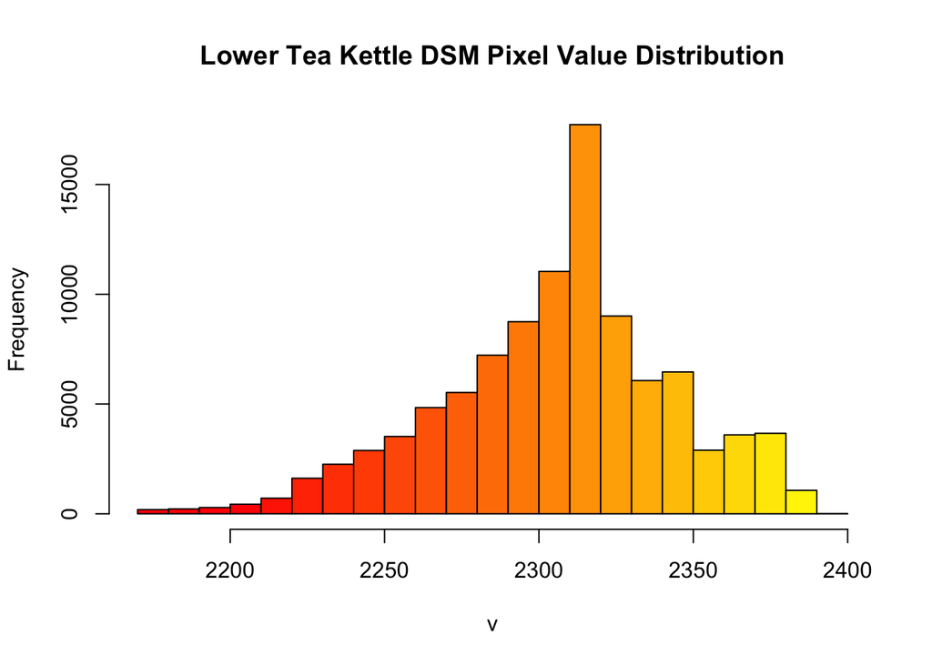

```r
# Plot the TEAK DSM raster's histogram
hist(teak_dsm, main="Lower Tea Kettle DSM Pixel Value Distribution", col=heat.colors(30))
```

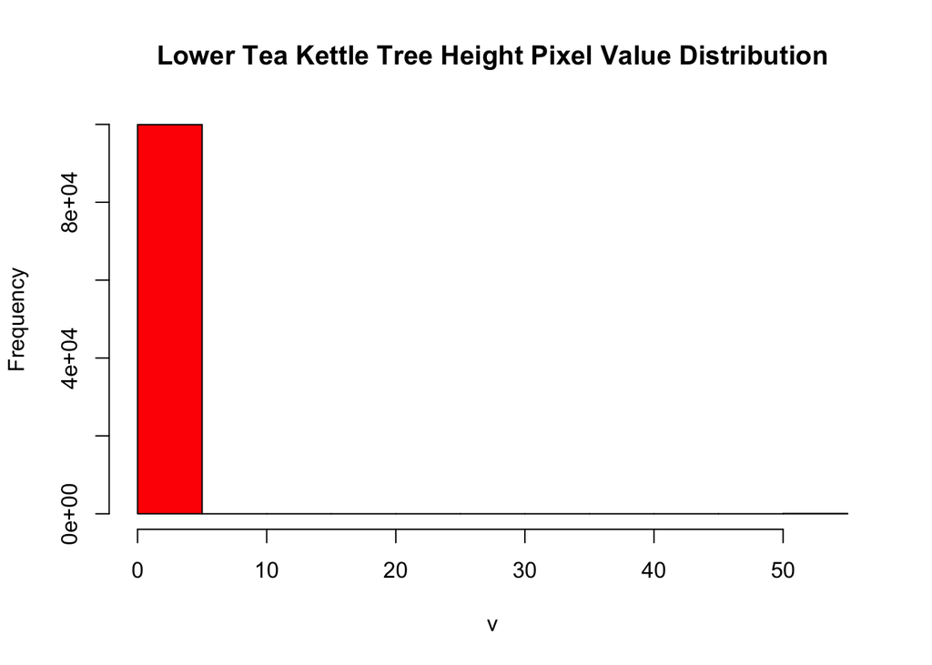

```r
# Plot the TEAK DSM raster's histogram
hist(teak_chm, main="Lower Tea Kettle Tree Height Pixel Value Distribution", col=heat.colors(3))
```

**We can see from the tree height raster that trees are sparse at this site.**